# Part II - Maximizing Profits

## by Oluwabukola Odutayo

## Investigation Overview

> During the cause of investigating this dataset, Products and areas that generated more profits was my main focus.This study can be used for predictive analysis upon further analysis. My main focus was on Product Name, Categories,Region and Segment Variables

## Regions with the highest Profit

> This visualization will help us to know which regions performed the best in terms of Profit generation. The visaulization made us to understand that the west generated more profit, followed by the east.

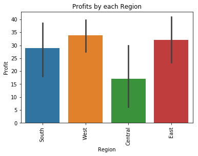

## Segment and Category with the Highest Profit

> This visualization will help us know the segments and category that generates the highest profits. The Technology Category generated most profits across all segments

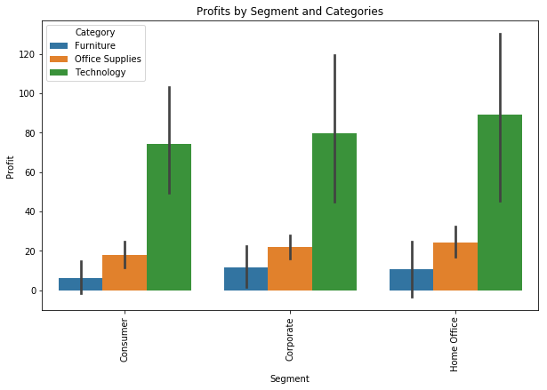

## States with the Highest Profit

> This visualization will help us know the states where the highest profits are genrated. Going by the visualization, i discovered that Indiana and Washington generated more profits than New york and California where the company has lots of customers

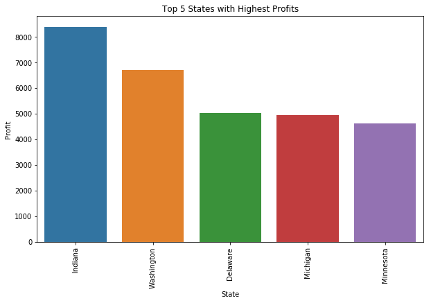

## Cities with the Highest Profit

> This visualization will help us know the top 5 cities where the highest profits are generated. As we can see, Lafayette, Seattle and Newark are the leading cities in terms of profits

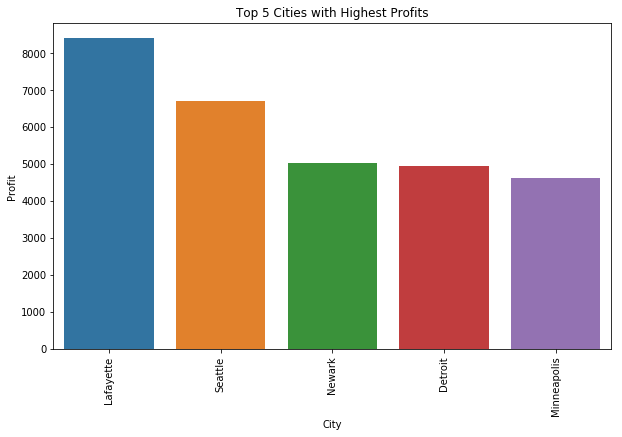